# TD2- Advanced Times Series

Nathan BONNEAU

2024-04-06

# VAR avec des données non stationnaires et IRF

### Question 1 : vérifier le degrée d’intégration et quelle est la solution ?

```r
library(vars)
```

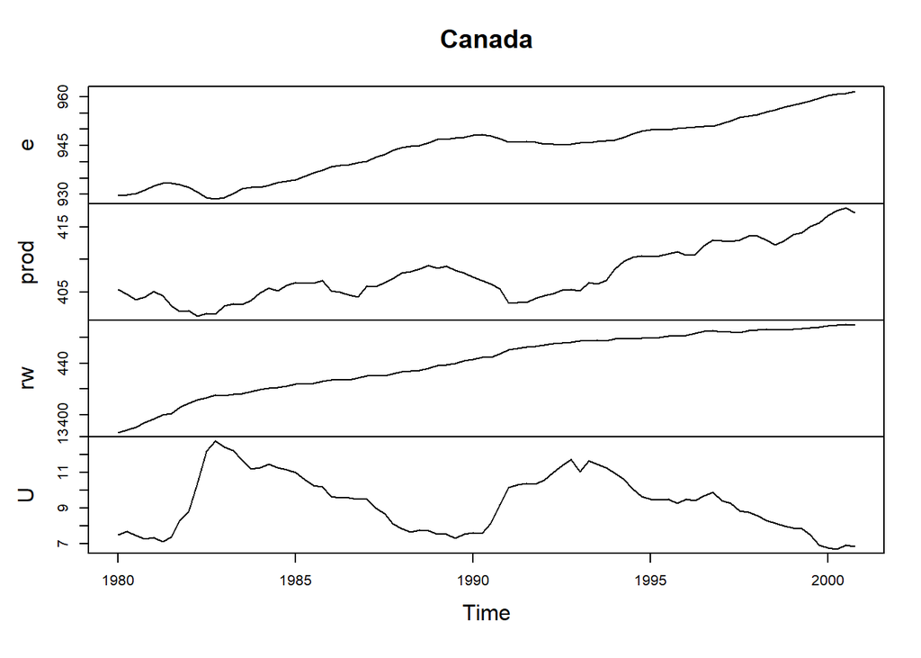

```r
#library(vars)
data(Canada)
plot(Canada)
```

```r
employment<- Canada[,1]
labor <- Canada[,2]
realwages <- Canada[,3]
unemployement <- Canada[,4]
```

On va réaliser des tests ADF pour les 4 courbes en les décompossant et en prenant le nombre de lag optimal en utilisant le critère BIC. Labor case :

```r
#plot(labor)
trendlabor <- ur.df(labor, type="trend", selectlags=c("BIC"))
summary(trendlabor)
```

```
##
## ###############################################
## # Augmented Dickey-Fuller Test Unit Root Test #
## ###############################################
##
## Test regression trend
##
##
## Call:
## lm(formula = z.diff ~ z.lag.1 + 1 + tt + z.diff.lag)
##
## Residuals:
##      Min       1Q   Median       3Q      Max
## -2.22554 -0.40892  0.02578  0.41669  1.70908
##
## Coefficients:
##              Estimate Std. Error t value Pr(>|t|)
## (Intercept) 29.281115  14.506222   2.019  0.04697 *
## z.lag.1     -0.073036   0.036127  -2.022  0.04664 *
## tt           0.014219   0.006151   2.312  0.02344 *
## z.diff.lag   0.310251   0.109678   2.829  0.00594 **
## ---
## Signif. codes:  0 '***' 0.001 '**' 0.01 '*' 0.05 '.' 0.1 ' ' 1
##
## Residual standard error: 0.6797 on 78 degrees of freedom
## Multiple R-squared:  0.1467, Adjusted R-squared:  0.1139
## F-statistic: 4.471 on 3 and 78 DF,  p-value: 0.005977
##
##
## Value of test-statistic is: -2.0216 2.4483 2.6786
##
## Critical values for test statistics:
##       1pct  5pct 10pct
## tau3 -4.04 -3.45 -3.15
## phi2  6.50  4.88  4.16
## phi3  8.73  6.49  5.47
```

A 5%, on remarque que notre valeur de la valeur critique est de -3.45 contre -2.02 pour la t-stat, on affirme donc que l’on conserve H0 donc une présence d’une racine unitaire (non stationnaire) Nous passons à l’étude du drift :

```r
driftlabor <- ur.df(labor, type="drift", selectlags=c("BIC"))
summary(driftlabor)
```

```
##
## ###############################################
## # Augmented Dickey-Fuller Test Unit Root Test #
## ###############################################
##
## Test regression drift
##
##
## Call:
## lm(formula = z.diff ~ z.lag.1 + 1 + z.diff.lag)
##
## Residuals:
##      Min       1Q   Median       3Q      Max
## -2.05018 -0.40444  0.08499  0.42631  1.74816
##
## Coefficients:
##              Estimate Std. Error t value Pr(>|t|)
## (Intercept)  1.025983   8.023600   0.128  0.89858
## z.lag.1     -0.002252   0.019690  -0.114  0.90922
## z.diff.lag   0.300758   0.112574   2.672  0.00916 **
## ---
## Signif. codes:  0 '***' 0.001 '**' 0.01 '*' 0.05 '.' 0.1 ' ' 1
##
## Residual standard error: 0.6981 on 79 degrees of freedom
## Multiple R-squared:  0.08828,    Adjusted R-squared:  0.06519
## F-statistic: 3.824 on 2 and 79 DF,  p-value: 0.02598
##
##
## Value of test-statistic is: -0.1144 0.9485
##
## Critical values for test statistics:
##       1pct  5pct 10pct
## tau2 -3.51 -2.89 -2.58
## phi1  6.70  4.71  3.86
```

Même constatation que précédemment, on a -2.89< -0.11 au seuil de 5% donc non stationnaire. Pour enlever ces composants, on propose de différencier une fois et répéter un test ADF :

```r
difflabor = na.omit(diff(labor, differences = 1))
difftrendlabor <- ur.df(difflabor , type = "trend", selectlags = c("BIC"))
summary(difftrendlabor)
```

```
##
## ###############################################
## # Augmented Dickey-Fuller Test Unit Root Test #
## ###############################################
##
## Test regression trend
##
##
## Call:
## lm(formula = z.diff ~ z.lag.1 + 1 + tt + z.diff.lag)
##
## Residuals:
##      Min       1Q   Median       3Q      Max
## -2.08255 -0.41492  0.03547  0.42292  1.77919
##
## Coefficients:
##              Estimate Std. Error t value Pr(>|t|)
## (Intercept) -0.007671   0.160585  -0.048    0.962
## z.lag.1     -0.723368   0.139237  -5.195 1.63e-06 ***
## tt           0.003058   0.003456   0.885    0.379
## z.diff.lag  -0.024356   0.114799  -0.212    0.833
## ---
## Signif. codes:  0 '***' 0.001 '**' 0.01 '*' 0.05 '.' 0.1 ' ' 1
##
## Residual standard error: 0.6981 on 77 degrees of freedom
## Multiple R-squared:  0.3679, Adjusted R-squared:  0.3433
## F-statistic: 14.94 on 3 and 77 DF,  p-value: 9.378e-08
##
##
## Value of test-statistic is: -5.1952 9.1153 13.6696
##
## Critical values for test statistics:
##       1pct  5pct 10pct
## tau3 -4.04 -3.45 -3.15
## phi2  6.50  4.88  4.16
## phi3  8.73  6.49  5.47
```

Maintenant, nous sommes bon, la courbe labor différenciée une fois est stationnaire car -3.45>-5.19 donc nous avons réussi à la rendre stationnaire et rejette H0.

```r
diffdriftlabor <- ur.df(difflabor, type="drift", selectlags=c("BIC"))
summary(diffdriftlabor)
```

```
##
## ###############################################
## # Augmented Dickey-Fuller Test Unit Root Test #
## ###############################################
##
## Test regression drift
##
##
## Call:
## lm(formula = z.diff ~ z.lag.1 + 1 + z.diff.lag)
##
## Residuals:
##      Min       1Q   Median       3Q      Max
## -2.05124 -0.39530  0.07819  0.41109  1.75129
##
## Coefficients:
##             Estimate Std. Error t value Pr(>|t|)
## (Intercept)  0.11534    0.08029   1.437    0.155
## z.lag.1     -0.68893    0.13350  -5.160 1.83e-06 ***
## z.diff.lag  -0.04274    0.11275  -0.379    0.706
## ---
## Signif. codes:  0 '***' 0.001 '**' 0.01 '*' 0.05 '.' 0.1 ' ' 1
##
## Residual standard error: 0.6971 on 78 degrees of freedom
## Multiple R-squared:  0.3615, Adjusted R-squared:  0.3451
## F-statistic: 22.08 on 2 and 78 DF,  p-value: 2.526e-08
##
##
## Value of test-statistic is: -5.1604 13.3184
##
## Critical values for test statistics:
##       1pct  5pct 10pct
## tau2 -3.51 -2.89 -2.58
## phi1  6.70  4.71  3.86
```

Pareil ici, on rejette h0 donc la série différenciée est stationnaire.